# CK_hypothesis_testing

Carl Klein

2023-12-09

**Load library**

**Load data**

```r
# output data
# master dataframe url
output_name <- 'https://raw.githubusercontent.com/CUBoulder-DS/5301-5000-Final-Report/main/data/MasterDataFrame.csv'

# entire master dataframe
output_df <- read_csv(output_name)
```

```
## ──────────────────────────────────────────────────────── Delimiter: "," chr
## (9): img_path, file, src_age_grp, src_gender, src_race, pred_model, pred... dbl
## (6): ...1, src_age, src_timestamp, pred_age_DF_only, pred_age_lower, pre...
```

```r
# fairface dataframe
# exclude the indexing column and deepface only column
fairface_df <- output_df %>%
  filter(pred_model == 'FairFace') %>%
  select(-c(...1, pred_age_DF_only)) %>%
  drop_na()

# deepface dataframe
# exclude the indexing column
deepface_df <- output_df %>%
  filter(pred_model == 'DeepFace') %>%
  select(-...1) %>%
  drop_na()

# source dataframe
# use one of the models (since the data is doubled)
# include only the source ("src") columns
source_df <- output_df %>%
  filter(pred_model == 'FairFace') %>%
  select(c(img_path, file, src_age, src_age_grp, src_gender, src_race, src_timestamp)) %>%
  drop_na()
```

**Separate out the categories**

```r
# categories from the data
age_bins <- source_df %>%
  select(src_age_grp) %>%
  unique()

genders <- source_df %>%
  select(src_gender) %>%
  unique()

races <- source_df %>%
  select(src_race) %>%
  unique()

# appending an "All" option for parsing reasons
age_bins <- age_bins %>% rbind('All')
genders <- genders %>% rbind('All')
races <- races %>% rbind('All')
```

## Two-Tailed Single Sample Proportion Test

- **Description**: *prop_test* will return the p-value associated with a two-tailed single sample proportion test.
- **Input**:
  - *p*: proportion that is initially assumed to be true (prior belief)
  - *p_hat*: calculated sample proportion given the required conditions
  - *n*: sample size given the required conditions
- **Output**:
  - *p_value*: p-value associated with the hypothesis test

```r
prop_test <- function(p, p_hat, n) {
  test_statistic <- abs((sqrt(n) * (p_hat - p)) / sqrt(p * (1 - p)))
  p_value <- pnorm(-test_statistic) + (1 - pnorm(test_statistic))
  return(p_value)
}
```

## Function to get Proportion Given Certain Parameters

- **Description**: *get_proportion* will return the proportion associated for a value within a given category.
- **Input**:
  - *df*: dataframe to calculate proportion frame
  - *evaluate_column*: column which contains the value desired for the proportion
  - *evaluate_value*: value within the specified column for which the proportion is desired
- **Output**:
  - *proportion*: desired proportion

```r
# function by PC
get_proportion <- function(df, evaluate_column, evaluate_value) {
  x <- df %>% filter(!!as.symbol(evaluate_column)==evaluate_value)%>% count() %>% unlist() %>% unname()
  if (x==0){
    0
  } else {
    result <- df %>% group_by(!!as.symbol(evaluate_column)) %>%
      summarise(n=n()) %>%
      mutate(prop=n/sum(n)) %>%
      filter(!!as.symbol(evaluate_column)==evaluate_value) %>%
      select(prop) %>% unlist() %>% unname()
  }
}
```

## Function to get Count Given Certain Parameters (alteration of *get_proportion*)

- **Description**: *get_count* will return the row count associated for a value within a given category.
- **Input**:
  - *df*: dataframe to calculate count frame
  - *evaluate_column*: column which contains the value desired for the count
  - *evaluate_value*: value within the specified column for which the count is desired
- **Output**:
  - *proportion*: desired count

```r
# function by PC, altered for count by CK
get_count <- function(df, evaluate_column, evaluate_value) {
  x <- df %>% filter(!!as.symbol(evaluate_column)==evaluate_value) %>% count() %>% unlist() %>% unname()
  if (x==0){
    0
  } else {
    result <- df %>% group_by(!!as.symbol(evaluate_column)) %>%
      summarise(n=n()) %>%
      filter(!!as.symbol(evaluate_column)==evaluate_value) %>%
      select(n) %>% unlist() %>% unname()
  }
}
```

**Example**:

```r
# return the proportion of females from the source data
example <- get_proportion(source_df, 'src_gender', 'Female')
example
```

```
## [1] 0.4780101
```

```r
# return the proportion of females from the source data
example <- get_count(source_df, 'src_gender', 'Female')
example
```

```
## [1] 11521
```

## Function to Produce All Pertinent Information for Hypothesis Tests Across All DataFrames - SINGLE SAMPLE

- **Description**: *run_prop_tests* will return an array containing all pertinent information regarding the desired proportion hypothesis test.
- **Input**:
  - *source_df*: the input dataframe (the data in which the null hypotheses will be built off, i.e. the prior belief data)
  - *fairface_df*: the output dataframe ran through the fairface model
  - *deepface_df*: the output dataframe ran through the deepface model
  - *test_prop*: choose a demographic from “age_bins”, “genders”, or “races” **(MUST CHOOSE ONE)**
  - *test_age*: specify a sub-demographic from “0-2”, “3-9”, “10-19”, “20-29”, “30-39”, “40-49”, “50-59”, “60-69”, “70-130”, or “All”
  - *test_gender*: specify a sub-demographic from “Female”, “Male”, or “All”
  - *test_race*: specify a sub-demographic from “Asian”, “Black”, “Indian”, “Other”, “White”, or “All”
  - **NOTE: AT LEAST ONE OF THE SUB-DEMOGRAPHIC SPECIFICATIONS MUST NOT BE “All”!**
- **Output**: a vector containing the following:
  - *test_prop*: restating the main demographic for which the proportion is tested from
  - *test_age*: restating the desired age sub-demographic
  - *test_gender*: restating the desired gender sub-demographic
  - *test_race*: restating the desired race sub-demographic
  - *source_prop*: the calculated source proportion for the sub-demographic (the prior belief)
  - *fairface_n*: the number of datapoints in the fairface dataframe associated with the main demographic
  - *fairface_prop*: the calculated fairface proportion for the sub-demographic
  - *fairface_p_value*: the p-value associated with hypothesis test for the fairface model
  - *deepface_n*: the number of datapoints in the deepface dataframe associated with the main demographic
  - *deepface_prop*: the calculated deepface proportion for the sub-demographic
  - *deepface_p_value*: the p-value associated with hypothesis test for the deepface model

```r
run_prop_tests <- function(source_df, fairface_df, deepface_df, test_prop, test_age, test_gender, test_race) {
  # create copies of the dataframes to alter
  source_subset <- source_df
  fairface_subset <- fairface_df
  deepface_subset <- deepface_df

  # if the main sub-demographic category is not set to "All" and the main demographic is
  # not the hypothesis test parameter being tested then filter the subsets
  if (test_age != 'All' & test_prop != 'age_bins') {
    source_subset <- source_subset %>% filter(src_age_grp == test_age)
    fairface_subset <- fairface_subset %>% filter(pred_age_grp == test_age)
    deepface_subset <- deepface_subset %>% filter(pred_age_grp == test_age)
  }
  if (test_gender != 'All' & test_prop != 'genders') {
    source_subset <- source_subset %>% filter(src_gender == test_gender)
    fairface_subset <- fairface_subset %>% filter(pred_gender == test_gender)
    deepface_subset <- deepface_subset %>% filter(pred_gender == test_gender)
  }
  if (test_race != 'All' & test_prop != 'races') {
    source_subset <- source_subset %>% filter(src_race == test_race)
    fairface_subset <- fairface_subset %>% filter(pred_race == test_race)
    deepface_subset <- deepface_subset %>% filter(pred_race == test_race)
  }

  # calculate the size of the filtered datasets (samples)
  fairface_n <- nrow(fairface_subset)
  deepface_n <- nrow(deepface_subset)

  # if the main demographic is being tested, run get_proportion now on that demographic
  if (test_prop == 'age_bins') {
    source_prop <- get_proportion(source_subset, 'src_age_grp', test_age)
    fairface_prop <- get_proportion(fairface_subset, 'pred_age_grp', test_age)
    deepface_prop <- get_proportion(deepface_subset, 'pred_age_grp', test_age)
  } else if (test_prop == 'genders') {
    source_prop <- get_proportion(source_subset, 'src_gender', test_gender)
    fairface_prop <- get_proportion(fairface_subset, 'pred_gender', test_gender)
    deepface_prop <- get_proportion(deepface_subset, 'pred_gender', test_gender)
  } else if (test_prop == 'races') {
    source_prop <- get_proportion(source_subset, 'src_race', test_race)
    fairface_prop <- get_proportion(fairface_subset, 'pred_race', test_race)
    deepface_prop <- get_proportion(deepface_subset, 'pred_race', test_race)
  }

  # calculate p-values for the fairface and deepface model results
  fairface_test <- prop_test(source_prop, fairface_prop, fairface_n)
  deepface_test <- prop_test(source_prop, deepface_prop, deepface_n)

  # return the vector of pertinent information
  return(c(test_prop = test_prop,
           test_age = test_age,
           test_gender = test_gender,
           test_race = test_race,
           source_prop = source_prop,
           fairface_n = fairface_n,
           fairface_prop = fairface_prop,
           fairface_p_value = fairface_test,
           deepface_n = deepface_n,
           deepface_prop = deepface_prop,
           deepface_p_value = deepface_test))
}
```

## Function to Produce All Pertinent Information for Hypothesis Tests Across All DataFrames - TWO SAMPLE

- **Description**: *run_two_sample_prop_tests* will return an array containing all pertinent information regarding the desired proportion hypothesis test.
- **Input**:
  - *source_df*: the input dataframe (the data in which the null hypotheses will be built off, i.e. the prior belief data)
  - *fairface_df*: the output dataframe ran through the fairface model
  - *deepface_df*: the output dataframe ran through the deepface model
  - *test_prop*: choose a demographic from “age_bins”, “genders”, or “races” **(MUST CHOOSE ONE)**
  - *test_age*: specify a sub-demographic from “0-2”, “3-9”, “10-19”, “20-29”, “30-39”, “40-49”, “50-59”, “60-69”, “70-130”, or “All”
  - *test_gender*: specify a sub-demographic from “Female”, “Male”, or “All”
  - *test_race*: specify a sub-demographic from “Asian”, “Black”, “Indian”, “Other”, “White”, or “All”
  - **NOTE: AT LEAST ONE OF THE SUB-DEMOGRAPHIC SPECIFICATIONS MUST NOT BE “All”!**
- **Output**: a vector containing the following:
  - *test_prop*: restating the main demographic for which the proportion is tested from
  - *test_age*: restating the desired age sub-demographic
  - *test_gender*: restating the desired gender sub-demographic
  - *test_race*: restating the desired race sub-demographic
  - *source_n*: the number of datapoints in the source dataframe associated with the main demographic
  - *source_prop*: the calculated source proportion for the sub-demographic
  - *fairface_n*: the number of datapoints in the fairface dataframe associated with the main demographic
  - *fairface_prop*: the calculated fairface proportion for the sub-demographic
  - *fairface_p_value*: the p-value associated with hypothesis test for the fairface model
  - *fairface_power*: the power associated with hypothesis test for the fairface model
  - *deepface_n*: the number of datapoints in the deepface dataframe associated with the main demographic
  - *deepface_prop*: the calculated deepface proportion for the sub-demographic
  - *deepface_p_value*: the p-value associated with hypothesis test for the deepface model
  - *deepface_power*: the power associated with hypothesis test for the deepface model

```r
run_two_sample_prop_tests <- function(source_df, fairface_df, deepface_df, test_prop, test_age, test_gender, test_race) {
  # create copies of the dataframes to alter
  source_subset <- source_df
  fairface_subset <- fairface_df
  deepface_subset <- deepface_df

  # if the main sub-demographic category is not set to "All" and the main demographic is
  # not the hypothesis test parameter being tested then filter the subsets
  if (test_age != 'All' & test_prop != 'age_bins') {
    source_subset <- source_subset %>% filter(src_age_grp == test_age)
    fairface_subset <- fairface_subset %>% filter(pred_age_grp == test_age)
    deepface_subset <- deepface_subset %>% filter(pred_age_grp == test_age)
  }
  if (test_gender != 'All' & test_prop != 'genders') {
    source_subset <- source_subset %>% filter(src_gender == test_gender)
    fairface_subset <- fairface_subset %>% filter(pred_gender == test_gender)
    deepface_subset <- deepface_subset %>% filter(pred_gender == test_gender)
  }
  if (test_race != 'All' & test_prop != 'races') {
    source_subset <- source_subset %>% filter(src_race == test_race)
    fairface_subset <- fairface_subset %>% filter(pred_race == test_race)
    deepface_subset <- deepface_subset %>% filter(pred_race == test_race)
  }

  # calculate the size of the filtered datasets
  source_n <- nrow(source_subset)
  fairface_n <- nrow(fairface_subset)
  deepface_n <- nrow(deepface_subset)

  # if the main demographic is being tested, run get_proportion now on that demographic
  if (test_prop == 'age_bins') {
    source_count <- get_count(source_subset, 'src_age_grp', test_age)
    fairface_count <- get_count(fairface_subset, 'pred_age_grp', test_age)
    deepface_count <- get_count(deepface_subset, 'pred_age_grp', test_age)
  } else if (test_prop == 'genders') {
    source_count <- get_count(source_subset, 'src_gender', test_gender)
    fairface_count <- get_count(fairface_subset, 'pred_gender', test_gender)
    deepface_count <- get_count(deepface_subset, 'pred_gender', test_gender)
  } else if (test_prop == 'races') {
    source_count <- get_count(source_subset, 'src_race', test_race)
    fairface_count <- get_count(fairface_subset, 'pred_race', test_race)
    deepface_count <- get_count(deepface_subset, 'pred_race', test_race)
  }

  # calculate p-values for the fairface and deepface model results
  if (source_n == 0 || fairface_n == 0) {
    fairface_test <- NA
  } else {
    fairface_test <- prop.test(x = c(source_count, fairface_count),
                               n = c(source_n, fairface_n))$p.value
  }

  if (source_n == 0 || deepface_n == 0) {
    deepface_test <- NA
  } else {
    deepface_test <- prop.test(x = c(source_count, deepface_count),
                               n = c(source_n, deepface_n))$p.value
  }

  # calculate power for fairface and deepface hypothesis tests
  # effect size is calculated by 2(arcsin(sqrt(p1)) - arcsin(sqrt(p2))), denoted by h
  source_prop = ifelse(is.nan(source_count/source_n)|is.infinite(source_count/source_n),
                       NA, source_count/source_n)
  fairface_prop = ifelse(is.nan(fairface_count/fairface_n)|is.infinite(fairface_count/fairface_n),
                         NA, fairface_count/fairface_n)
  deepface_prop = ifelse(is.nan(deepface_count/deepface_n)|is.infinite(deepface_count/deepface_n),
                         NA, deepface_count/deepface_n)

  # fairface_h = 2 * (asin(sqrt(source_prop)) - asin(sqrt(fairface_prop)))
  # deepface_h = 2 * (asin(sqrt(source_prop)) - asin(sqrt(deepface_prop)))

  if (fairface_n > 1) {
    fairface_power = pwr.2p2n.test(ES.h(source_prop, fairface_prop),
                                   n1 = source_n, n2 = fairface_n,
                                   sig.level = 0.003,
                                   alternative = "two.sided")$power
  } else {
    fairface_power = 0
  }

  if (deepface_n > 1) {
  deepface_power = pwr.2p2n.test(ES.h(source_prop, deepface_prop),
                                 n1 = source_n, n2 = deepface_n,
                                 sig.level = 0.003,
                                 alternative = "two.sided")$power
  } else {
    deepface_power = 0
  }

  # return the vector of pertinent information
  return(c(test_prop = test_prop,
           test_age = test_age,
           test_gender = test_gender,
           test_race = test_race,
           source_n = source_n,
           source_prop = source_prop,
           fairface_n = fairface_n,
           fairface_prop = fairface_prop,
           fairface_p_value = fairface_test,
           fairface_power = fairface_power,
           deepface_n = deepface_n,
           deepface_prop = deepface_prop,
           deepface_p_value = deepface_test,
           deepface_power = deepface_power))
}
```

**Example**:

```r
# return the pertinent information for a test ran on the proportion of females
example <- run_prop_tests(source_df, fairface_df, deepface_df, 'genders', 'All', 'Female', 'All')
example
```

```
##               test_prop                test_age             test_gender
##               "genders"                   "All"                "Female"
##               test_race             source_prop              fairface_n
##                   "All"     "0.478010123641192"                 "24091"
##           fairface_prop        fairface_p_value              deepface_n
##     "0.479764227304803"     "0.585721945175127"                 "24053"
##           deepface_prop        deepface_p_value
##     "0.383320167962416" "2.79204958502485e-190"
```

```r
# return the pertinent information for a test ran on the proportion of females given they are indian
example <- run_prop_tests(source_df, fairface_df, deepface_df, 'genders', 'All', 'Female', 'Indian')
example
```

```
##             test_prop              test_age           test_gender
##             "genders"                 "All"              "Female"
##             test_race           source_prop            fairface_n
##              "Indian"   "0.432580084430097"                "2483"
##         fairface_prop      fairface_p_value            deepface_n
##   "0.443012484897302"   "0.294054085230945"                "1470"
##         deepface_prop      deepface_p_value
##   "0.349659863945578" "1.3896529981707e-10"
```

```r
# return the pertinent information for a test ran on the proportion of females
example <- run_two_sample_prop_tests(source_df, fairface_df, deepface_df, 'genders', 'All', 'Female', 'All')
example
```

```
##              test_prop               test_age            test_gender
##              "genders"                  "All"               "Female"
##              test_race               source_n            source_prop
##                  "All"                "24102"    "0.478010123641192"
##             fairface_n          fairface_prop       fairface_p_value
##                "24091"    "0.479764227304803"    "0.706692464186261"
##         fairface_power             deepface_n          deepface_prop
##  "0.00530644028473707"                "24053"    "0.383320167962416"
##       deepface_p_value         deepface_power
## "1.17669812409091e-97"                    "1"
```

```r
# return the pertinent information for a test ran on the proportion of females given they are indian
example <- run_two_sample_prop_tests(source_df, fairface_df, deepface_df, 'genders', 'All', 'Female', 'Indian')
example
```

```
##              test_prop               test_age            test_gender
##              "genders"                  "All"               "Female"
##              test_race               source_n            source_prop
##               "Indian"                 "4027"    "0.432580084430097"
##             fairface_n          fairface_prop       fairface_p_value
##                 "2483"    "0.443012484897302"    "0.424490058914896"
##         fairface_power             deepface_n          deepface_prop
##   "0.0161071203046988"                 "1470"    "0.349659863945578"
##       deepface_p_value         deepface_power
## "3.78091228273428e-08"    "0.995552316256151"
```

```r
# create an empty tibble to store results matching the run_prop_tests return vector
result_matrix <- tibble(
  test_prop = character(),
  test_age = character(),
  test_gender = character(),
  test_race = character(),
  source_prop = character(),
  fairface_n = character(),
  fairface_prop = character(),
  fairface_p_value = character(),
  deepface_n = character(),
  deepface_prop = character(),
  deepface_p_value = character()
)

# loop through each sub-demographic across the main demographics
# if the main demographic is not an "All" option, add a row containing pertinent information
for (age in pull(age_bins)) {
  for (gender in pull(genders)) {
    for (race in pull(races)) {
      if (age != 'All') {
        new_row <- run_prop_tests(source_df, fairface_df, deepface_df, 'age_bins', age, gender, race)
        result_matrix <- result_matrix %>% add_row(!!! new_row)
      }
      if (gender != 'All') {
        new_row <- run_prop_tests(source_df, fairface_df, deepface_df, 'genders', age, gender, race)
        result_matrix <- result_matrix %>% add_row(!!! new_row)
      }
      if (race != 'All') {
        new_row <- run_prop_tests(source_df, fairface_df, deepface_df, 'races', age, gender, race)
        result_matrix <- result_matrix %>% add_row(!!! new_row)
      }
    }
  }
}
```

> The returned *result_matrix* contains every combination of demographics and sub-demographics hypothesis testing, at 432 hypotheses tested. If there is a result that is “NA”, it most likely means the sub-demographic and it’s conditionals had a proportion of 0.

```r
# save result_matrix
#write_csv(result_matrix, "C:/Users/carlj/OneDrive/Documents/CUBoulder/Statistics/Project/5301-5000-Final-Report/data/pvalue_results.csv")
#write_csv(result_matrix, "c:/Users/pconn/OneDrive/Desktop/Stat-Git/data/pvalue_results.csv")
result_matrix %>% write_csv('../data/pvalue_results.csv')
```

```r
# create an empty tibble to store results matching the run_prop_tests return vector
two_sample_result_matrix <- tibble(
  test_prop = character(),
  test_age = character(),
  test_gender = character(),
  test_race = character(),
  source_n = character(),
  source_prop = character(),
  fairface_n = character(),
  fairface_prop = character(),
  fairface_p_value = character(),
  fairface_power = character(),
  deepface_n = character(),
  deepface_prop = character(),
  deepface_p_value = character(),
  deepface_power = character()
)

# loop through each sub-demographic across the main demographics
# if the main demographic is not an "All" option, add a row containing pertinent information
for (age in pull(age_bins)) {
  for (gender in pull(genders)) {
    for (race in pull(races)) {
      if (age != 'All') {
        new_row <- run_two_sample_prop_tests(source_df, fairface_df, deepface_df,
                                             'age_bins', age, gender, race)
        two_sample_result_matrix <- two_sample_result_matrix %>% add_row(!!! new_row)
      }
      if (gender != 'All') {
        new_row <- run_two_sample_prop_tests(source_df, fairface_df, deepface_df,
                                             'genders', age, gender, race)
        two_sample_result_matrix <- two_sample_result_matrix %>% add_row(!!! new_row)
      }
      if (race != 'All') {
        new_row <- run_two_sample_prop_tests(source_df, fairface_df, deepface_df,
                                             'races', age, gender, race)
        two_sample_result_matrix <- two_sample_result_matrix %>% add_row(!!! new_row)
      }
    }
  }
}
```

```r
# save two_sample_result_matrix
#write_csv(two_sample_result_matrix, "C:/Users/carlj/OneDrive/Documents/CUBoulder/Statistics/Project/5301-5000-Final-Report/data/pvalue_results_two_sample.csv")
#write_csv(two_sample_result_matrix,"C:/Users/pconn/OneDrive/Desktop/Stat-Git/data/p_value_results_two_sample.csv")
two_sample_result_matrix %>% write_csv('../data/p_value_results_two_sample.csv')
```

## Hypothesis Testing - Single Sample

Our data consists of three main sets, the source input data, the Fairface output data, and the Deepface output data.

We’ll be creating our hypothesis tests by treating the source data as the basis for the original assumptions (our *null hypotheses*), and then using the output from Fairface and Deepface to test for statistically significant differences. Gaining a statistically significant result would allow us to reject our *null hypothesis* in favor of the *alternative hypothesis*. In other words, rejecting the original assumption means there is a statistically large enough difference between the source data and output data, and could indicate a bias in model.

We’ll be testing across different subsets contained within the data, as listed below:

### Demographics

- Age Group
- Gender
- Race

### Demographics’ Subgroups

- Age Group (9 groups)
  - 0-2
  - 3-9
  - 10-19
  - 20-29
  - 30-39
  - 40-49
  - 50-59
  - 60-69
  - 70-130
- Gender (2 groups)
  - Female
  - Male
- Race (5 groups)
  - Asian
  - Black
  - Indian
  - Other
  - White

### The General Proportion Tests

Our hypothesis tests will be testing different proportions within these subgroups between the source data and the output data.

The general format of our hypothesis tests will be:

$H_0: p = p_{\text{Source Data Subset}}$

$H_A: p \neq p_{\text{Source Data Subset}}$

With the following test statistic:

$\frac{\sqrt{n}(\hat{p} - p)}{\sqrt{p(1 - p)}}$

With the p-value being calculated by:

$P(|Z| > \hat{p} | H_0)$

$= P(|Z| > \frac{\sqrt{n}(\hat{p} - p)}{\sqrt{p(1 - p)}})$,

where

- $n$: output data subset size
- $\hat{p}$: output data subset proportion
- $p$: source data subset proportion

### Notation

Before we list the specific tests, we should introduce some notation.

Let $R$ be race, then $R \in \{Asian, Black, Indian, Other, White\} = \{A, B, I, O, W\}$

Let $G$ be gender, then $G \in \{Female, Male\} = \{F, M\}$

Let $A$ be age, then $A \in \{[0,2], [3,9], [10,19], [20,29], [30,39], [40,49], [50,59], [60,69], [70,130]\} = \{1, 2, 3, 4, 5, 6, 7, 8, 9\}$

Let $D$ be the dataset, then $D \in \{Source, Fairface, Deepface\} = \{D_0, D_f, D_d\}$

### More Specific Proportion Tests

Using this notation, we can simplify our nomenclature for testing a certain proportion of an overall demographic.

For example, we can test if the proportion of *Female* in the Fairface output is statistically different than the proportion of *Female* from the source.

Hypothesis Test:

$H_0: p_F = p_{F|D_0}$

$H_A: p_F \neq p_{F|D_0}$

P-value Calculation:

$P(|Z| > \frac{\sqrt{n}(\hat{p} - p)}{\sqrt{p(1 - p)}})$,

where

- $p = p_{F|D_0}$: proportion of females from the source data
- $\hat{p} = p_{F|D_f}$: proportion of females from the fairface output
- $n = n_{F \cup M|D_f}$: number of data points in the gender subset form the fairface output

Using the *result_matrix*, we can return all of the pertinent testing information from both fairface and deepface.

```r
result_matrix %>%
  filter(test_prop == 'genders' & test_age =='All' & test_gender == 'Female' & test_race == 'All') %>%
  select(c(source_prop, fairface_prop, fairface_p_value, deepface_prop, deepface_p_value))
```

```
## # A tibble: 1 × 5
##   source_prop      fairface_prop fairface_p_value deepface_prop deepface_p_value
##   <chr>            <chr>         <chr>            <chr>         <chr>
## 1 0.4780101236411… 0.4797642273… 0.5857219451751… 0.3833201679… 2.7920495850248…
```

Additionally, we could test for different combinations of subsets within demographics. For instance, if we wanted to test for a statistically significant difference between the proportion of those who *Female*, given that they were *Black*, then we could write a hypothesis test like:

$H_0: p_{F|B} = p_{F|D_0 \cap B}$

$H_A: p_{F|B} \neq p_{F|D_0 \cap B}$

P-value Calculation:

$P(|Z| > \frac{\sqrt{n}(\hat{p} - p)}{\sqrt{p(1 - p)}})$,

where

- $p = p_{F|D_0 \cap B}$: proportion of females from the source data, given they were black
- $\hat{p} = p_{F|D_f \cap B}$: proportion of females from the fairface output, given they were black
- $n = n_{F \cup M|D_f \cap B}$: number of data points in the gender subset form the fairface output, given they were black.

again, using the *result_matrix*, we can return all of the pertinent testing information from both fairface and deepface.

```r
result_matrix %>%
  filter(test_prop == 'genders' & test_age =='All' & test_gender == 'Female' & test_race == 'Black') %>%
  select(c(source_prop, fairface_prop, fairface_p_value, deepface_prop, deepface_p_value))
```

```
## # A tibble: 1 × 5
##   source_prop      fairface_prop fairface_p_value deepface_prop deepface_p_value
##   <chr>            <chr>         <chr>            <chr>         <chr>
## 1 0.4872751206669… 0.4649585531… 0.0048467355337… 0.2405845980… 8.6525330630269…
```

These were two specific hypothesis tests, however, we’ll be testing many combinations of these parameters and reporting back on any significant findings. The results of any combination of these test can be found in the *results_matrix*.

## Hypothesis Testing - Two Sample

It seemed more appropriate to test the true difference between two samples rather than assume one of the samples as the “prior assumption” for the null hypothesis.

Our test when viewed in this perspective becomes:

$H_0: \hat{p_1} = \hat{p_2}$

$H_A: \hat{p_1} \neq \hat{p_2}$

with our test statistic being:

$\frac{\hat{p_1} - \hat{p_2}}{\sqrt{\hat{p}(1 - \hat{p})(\frac{1}{n_1} \frac{1}{n_2})}}$

and $\hat{p} = \frac{\text{# satisfied in both samples}}{\text{total in both samples}}$

Using our examples from above:

**Example 1**:

For example, we can test if the proportion of *Female* in the Fairface output is statistically different than the proportion of *Female* from the source.

```r
two_sample_result_matrix %>%
  filter(test_prop == 'genders' & test_age =='All' & test_gender == 'Female' & test_race == 'All') %>%
  select(c(source_prop, fairface_prop, fairface_p_value, fairface_power, deepface_prop, deepface_p_value, deepface_power)) %>%
  transpose()
```

```
## [[1]]
## [[1]]$source_prop
## [1] "0.478010123641192"
##
## [[1]]$fairface_prop
## [1] "0.479764227304803"
##
## [[1]]$fairface_p_value
## [1] "0.706692464186261"
##
## [[1]]$fairface_power
## [1] "0.00530644028473707"
##
## [[1]]$deepface_prop
## [1] "0.383320167962416"
##
## [[1]]$deepface_p_value
## [1] "1.17669812409091e-97"
##
## [[1]]$deepface_power
## [1] "1"
```

**Example 2**:

Or, test for a statistically significant difference between the proportion of those who *Female*, given that they were *Black*, then we could write a hypothesis test like.

```r
two_sample_result_matrix %>%
  filter(test_prop == 'genders' & test_age =='All' & test_gender == 'Female' & test_race == 'Black') %>%
  select(c(source_prop, fairface_prop, fairface_p_value, fairface_power, deepface_prop, deepface_p_value, deepface_power)) %>%
  transpose()
```

```
## [[1]]
## [[1]]$source_prop
## [1] "0.487275120666959"
##
## [[1]]$fairface_prop
## [1] "0.464958553127355"
##
## [[1]]$fairface_p_value
## [1] "0.0415523560425101"
##
## [[1]]$fairface_power
## [1] "0.1820115002838"
##
## [[1]]$deepface_prop
## [1] "0.240584598088814"
##
## [[1]]$deepface_p_value
## [1] "3.92558655764136e-114"
##
## [[1]]$deepface_power
## [1] "1"
```

```r
#PC add F1 and Accuracy Scores
library(broom)
library(caret)
#build a function to calc F1 and Acc scores similar to Carl's layout

acc_f1 <- function(df,t_prop,t_race,t_gender,t_age){
  tdf <- df %>% drop_na()

  if (t_age!='All' & t_prop!='age_bins'){
    tdf <- tdf %>% filter(src_age_grp==t_age)
  }

  if (t_gender!='All' & t_prop!='genders'){
    tdf <- tdf %>% filter(src_gender==t_gender)
  }

  if (t_race!='All' & t_prop != 'races'){
    tdf <- tdf %>% filter(src_race == t_race)
  }

  r_levels <- as.factor(unique(df$src_race))
  a_levels <- as.factor(unique(df$src_age_grp))
  g_levels <- as.factor(unique(df$src_gender))
  tdf <- tdf %>% mutate(
    src_race = factor(src_race,levels=r_levels),
    src_gender = factor(src_gender,levels=g_levels),
    src_age_grp = factor(src_age_grp,levels=a_levels),
    pred_race = factor(pred_race,levels=r_levels),
    pred_gender = factor(pred_gender,levels=g_levels),
    pred_age_grp = factor(pred_age_grp,levels=a_levels)
  )
  if (t_prop == 'age_bins'){
    res <- confusionMatrix(tdf$pred_age_grp,tdf$src_age_grp,mode='everything')[['byClass']]
  } else if (t_prop =='genders'){
    resF <- confusionMatrix(tdf$pred_gender,tdf$src_gender,mode='everything',positive='Female')[['byClass']]
    resM <- confusionMatrix(tdf$pred_gender,tdf$src_gender,mode='everything',positive='Male')[['byClass']]
    g_names <- c(
      "Class: Female","Class: Male"
    )
    res <- cbind(resF,resM)
    colnames(res) <- g_names
    res <- t(res)
  } else if (t_prop == 'races'){
    res <- confusionMatrix(tdf$pred_race,tdf$src_race,mode='everything')[['byClass']]
  } else {
    res <-  c()
  }

  if (length(res) > 0 & 'Balanced Accuracy' %in% colnames(res) & 'F1' %in% colnames(res)){

    acc <- res[,'Balanced Accuracy']
    f1 <- res[,'F1']

    names(acc) <- acc %>% names() %>% str_replace("Class: ","")
    names(f1) <- f1 %>% names() %>% str_replace("Class: ","")

    n <- c(names(acc),names(f1))

    comb <- tibble(namesf1=names(f1),namesAcc=names(acc),f1,acc)

    res <- tibble(
      test_prop = t_prop,
      test_race = t_race,
      test_gender = t_gender,
      test_age = t_age,
      F1 = f1,
      Accuracy = acc,
      names = names(f1)
    )
    if (t_prop=='age_bins') {
      res <- res %>% filter(names==t_age) %>% select(test_prop:Accuracy)
    }

    if (t_prop=='genders') {
      res <- res %>% filter(names==t_gender) %>% select(test_prop:Accuracy)
    }

    if (t_prop=='races'){
      res <- res %>% filter(names==t_race) %>% select(test_prop:Accuracy)
    }
    res
  }
}

#get the same values we'll need for iteration on calling acc_f1
verify <- two_sample_result_matrix %>% select(test_prop,test_age,test_gender,test_race)

#rowwise basically allows us to iterate per-row of the dataframe and call the function
#run against fairface
FF_f1_acc <- verify %>% rowwise %>% reframe(out=acc_f1(fairface_df,test_prop,test_race,test_gender,test_age)) %>% ungroup() %>% unnest(cols=c(out))

#run against deepface
DF_f1_acc <- verify %>% rowwise %>% reframe(out=acc_f1(deepface_df,test_prop,test_race,test_gender,test_age)) %>% ungroup() %>% unnest(cols=c(out))

#combine the results of FairFace and DeepFace F1/ACC
total_f1_acc <- FF_f1_acc %>% inner_join(DF_f1_acc,suffix=c('.FF','.DF'),by=c('test_prop'='test_prop','test_age'='test_age','test_gender'='test_gender','test_race'='test_race'))

#merge the F1/ACC with the two sample results
combined_results <- two_sample_result_matrix %>% inner_join(total_f1_acc,by=c('test_prop'='test_prop','test_age'='test_age','test_gender'='test_gender','test_race'='test_race'))

#extract the columns only pertinent to the source and to deepface
df_results <- combined_results %>% select(test_prop:source_prop,deepface_n,deepface_prop,deepface_p_value,deepface_power,F1.DF,Accuracy.DF)

#extract the columns only pertinent to the source and to fairface
ff_results <- combined_results %>% select(test_prop:source_prop,fairface_n,fairface_prop,fairface_p_value,fairface_power,F1.FF,Accuracy.FF)

#rename the columns from fairface and deepface to have the same names.
names(ff_results) <- c("test_prop","test_age","test_gender","test_race","source_n","source_prop","model_n","model_prop","model_p_value","model_power","model_F1","model_Accuracy")

names(df_results) <- c("test_prop","test_age","test_gender","test_race","source_n","source_prop","model_n","model_prop","model_p_value","model_power","model_F1","model_Accuracy")

#add a model column to both frames to tag which model was used to get the values
ff_results <- mutate(ff_results,model='FairFace')

df_results <- mutate(df_results,model='DeepFace')

#union the two results to get the full answer in a cleaner format.
full_results <- union(ff_results,df_results)

#full_results %>% write_csv('C:\\Users\\pconn\\OneDrive\\Desktop\\Stat-Git\\data\\combined_p_val_F1_acc.csv')
full_results %>% write_csv('../data/combined_p_val_F1_acc.csv')
```

```r
get_sample_props <- function(vector,i,category){
  x <- vector[,i]
  length(x[x==category]) / length(x)
}

prop_bootstrap_data <- function(df,t_prop,t_race,t_gender,t_age){

  sdf <- df
  pdf <- df

  if (t_age!='All' & t_prop!='age_bins'){
    sdf <- sdf %>% filter(src_age_grp==t_age)
    pdf <- pdf %>%filter(pred_age_grp==t_age)
  }

  if (t_gender!='All' & t_prop!='genders'){
    sdf <- sdf %>% filter(src_gender==t_gender)
    pdf <- pdf %>% filter(pred_gender==t_gender)
  }

  if (t_race!='All' & t_prop != 'races'){
    sdf <- sdf %>% filter(src_race == t_race)
    pdf <- pdf %>% filter(pred_race==t_race)
  }

  if (t_prop=='races'){
    src1 <- sdf %>% pull(src_race)
    pred1 <- pdf %>% pull(pred_race)
    catg <- t_race
  } else if (t_prop=='genders'){
    src1 <- sdf %>% pull(src_gender)
    pred1 <- pdf %>% pull(pred_gender)
    catg <- t_gender
  } else if (t_prop=='age_bins'){
    src1 <- sdf %>% pull(src_age_grp)
    pred1 <- pdf %>% pull(pred_age_grp)
    catg <- t_age
  } else {
    return(0)
  }

  if (length(src1) > 0 & length(pred1) > 0){
    source_bootstrap <- replicate(2000,sample(src1,size=500,replace=T))
    pred_bootstrap <- replicate(2000,sample(pred1,size=500,replace=T))

    source_props <- sapply(c(1:2000),get_sample_props,vector=source_bootstrap,category=catg)
    pred_props <- sapply(c(1:2000),get_sample_props,vector=pred_bootstrap,category=catg)

    tibble(
      model=replicate(2000,''),
      test_prop=t_prop,
      test_gender=t_gender,
      test_race=t_race,
      test_age=t_age,
      src_mean_props = source_props,
      pred_mean_props= pred_props
    )

  } else if (length(src1)==0){
    pred_bootstrap <- replicate(2000,sample(pred1,size=500,replace=T))
    pred_props <- sapply(c(1:2000),get_sample_props,vector=pred_bootstrap,category=catg)
    tibble(
      model=replicate(2000,''),
      test_prop=t_prop,
      test_gender=t_gender,
      test_race=t_race,
      test_age=t_age,
      src_mean_props = replicate(2000,NA),
      pred_mean_props = pred_props
    )
  } else {
    source_bootstrap <- replicate(2000,sample(src1,size=500,replace=T))
    source_props <- sapply(c(1:2000),get_sample_props,vector=source_bootstrap,category=catg)
    tibble(
      model=replicate(2000,''),
      test_prop=t_prop,
      test_gender=t_gender,
      test_race=t_race,
      test_age=t_age,
      src_mean_props=source_props,
      pred_mean_props=replicate(2000,NA)
    )
  }
}

proportion_bootstrap <- function(df,t_prop,t_race,t_gender,t_age){
  #add cases for prop all
  #get props
  sdf <- df
  pdf <- df
  if (t_age!='All' & t_prop!='age_bins'){
    sdf <- sdf %>% filter(src_age_grp==t_age)
    pdf <- pdf %>% filter(pred_age_grp==t_age)
  }

  if (t_gender!='All' & t_prop!='genders'){
    sdf <- sdf %>% filter(src_gender==t_gender)
    pdf <- pdf %>% filter(pred_gender==t_gender)
  }

  if (t_race!='All' & t_prop != 'races'){
    sdf <- sdf %>% filter(src_race == t_race)
    pdf <- pdf %>% filter(pred_race == t_race)
  }

  if (t_prop=='races'){
    src1 <- sdf %>% pull(src_race)
    pred1 <- pdf %>% pull(pred_race)
    catg <- t_race
  } else if (t_prop=='genders'){
    src1 <- sdf %>% pull(src_gender)
    pred1 <- pdf %>% pull(pred_gender)
    catg <- t_gender
  } else if (t_prop=='age_bins'){
    src1 <- sdf %>% pull(src_age_grp)
    pred1 <- pdf %>% pull(pred_age_grp)
    catg <- t_age
  } else {
    tibble(
    model="test",
      test_prop=t_prop,
      test_race=t_race,
      test_gender=t_gender,
      test_age=t_age,
      model_p_value=NA,
      model_power=NA
    )
  }

  if (length(src1)>0 & length(pred1)>0){
    source_bootstrap <- replicate(2000,sample(src1,size=500,replace=T))
    pred_bootstrap <- replicate(2000,sample(pred1,size=500,replace=T))

    source_props <- sapply(c(1:2000),get_sample_props,vector=source_bootstrap,category=catg)
    pred_props <- sapply(c(1:2000),get_sample_props,vector=pred_bootstrap,category=catg)

    #source_props

    #p_val <- t.test(source_props,pred_props,var.equal=TRUE,conf.level=.997,alternative='two.sided')$p.value
    #t.test(x=prices20161002$AveragePrice,y=prices20161009$AveragePrice,paired=T,alternative='less')$p.value
    p_val <- t.test(source_props,pred_props,var.equal=T,conf.level=.99999,alternative='two.sided')$p.value
    power <- pwr.t2n.test(n1=length(source_props),n2=length(pred_props),d=0.8,sig.level=1-.99999,alternative='two.sided')$power
  } else {
    p_val <- NA
    power <- NA
  }

  tibble(
    model="test",
    test_prop=t_prop,
    test_race=t_race,
    test_gender=t_gender,
    test_age=t_age,
    model_p_value=p_val,
    model_power=power
  )
}

set.seed(100)
df_bootstrap <- full_results %>% filter(model=='DeepFace') %>% rowwise %>%
  reframe(out=proportion_bootstrap(
    deepface_df,
    test_prop,
    test_race,
    test_gender,
    test_age)) %>%
  ungroup() %>%
  unnest(cols=c(out))

set.seed(100)
df_bootstrap_data <- full_results %>% filter(model=='FairFace') %>% rowwise %>%
  reframe(
    out=prop_bootstrap_data(
      deepface_df,
      test_prop,
      test_race,
      test_gender,
      test_age
    )
  ) %>%
  ungroup() %>%
  unnest(cols=c(out))

set.seed(100)
ff_bootstrap <- full_results %>% filter(model=='FairFace') %>% rowwise %>%
  reframe(out=proportion_bootstrap(
    fairface_df,
    test_prop,
    test_race,
    test_gender,
    test_age)) %>%
  ungroup() %>%
  unnest(cols=c(out))

set.seed(100)
ff_bootstrap_data <- full_results %>% filter(model=='FairFace') %>% rowwise %>%
  reframe(
    out=prop_bootstrap_data(
      fairface_df,
      test_prop,
      test_race,
      test_gender,
      test_age
    )
  ) %>%
  ungroup() %>%
  unnest(cols=c(out))
```

```r
df_bootstrap_data <- df_bootstrap_data %>% pivot_longer(cols=c(src_mean_props,pred_mean_props)) %>% separate_wider_delim(name,delim='_',names=c('datasource','rem1','rem2')) %>% select(model:datasource,value)

ff_bootstrap_data <- ff_bootstrap_data %>% pivot_longer(cols=c(src_mean_props,pred_mean_props)) %>% separate_wider_delim(name,delim='_',names=c('datasource','rem1','rem2')) %>% select(model:datasource,value)
```

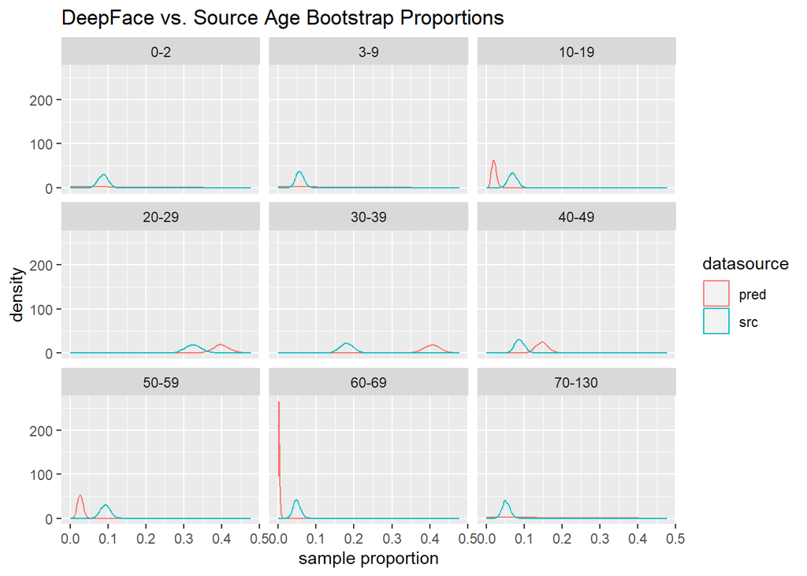

```r
#2000 samples, 500 subjects per sample, with replacement
#facet-wrap plots by top-level cateogry (age,gender,race) by model

f <- factor(c('0-2','3-9','10-19','20-29','30-39','40-49','50-59','60-69','70-130'))

#age plots
df_bootstrap_data %>% filter(test_prop=='age_bins',test_gender=='All',test_race=='All') %>%
  mutate(test_age=factor(test_age,levels=f)) %>%
  ggplot()+geom_density(aes(x=value,color=datasource)) + facet_wrap(~test_age) + xlab('sample proportion') + ggtitle('DeepFace vs. Source Age Bootstrap Proportions')
```

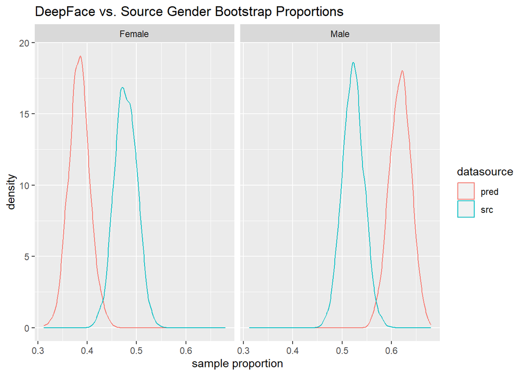

```r
#gender plots
df_bootstrap_data %>% filter(test_prop=='genders',test_age=='All',test_race=='All') %>% ggplot()+geom_density(aes(x=value,color=datasource)) + facet_wrap(~test_gender)+ xlab('sample proportion')+ ggtitle('DeepFace vs. Source Gender Bootstrap Proportions')
```

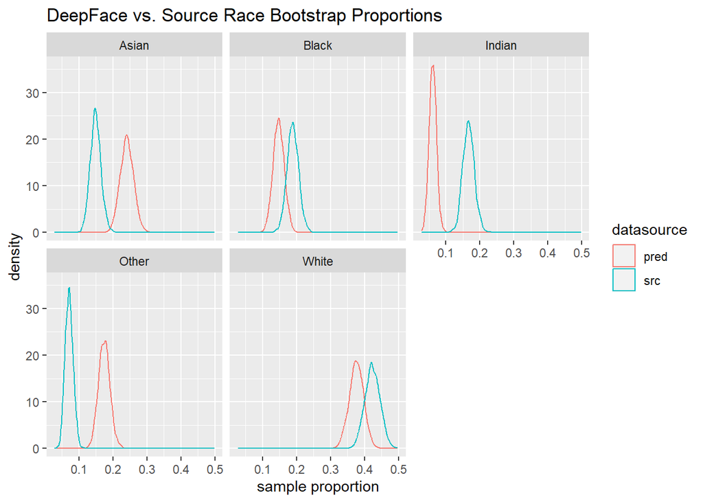

```r
#race plots
df_bootstrap_data %>% filter(test_prop=='races',test_age=='All',test_gender=='All') %>% ggplot()+geom_density(aes(x=value,color=datasource)) + facet_wrap(~test_race)+ xlab('sample proportion')+ ggtitle('DeepFace vs. Source Race Bootstrap Proportions')
```

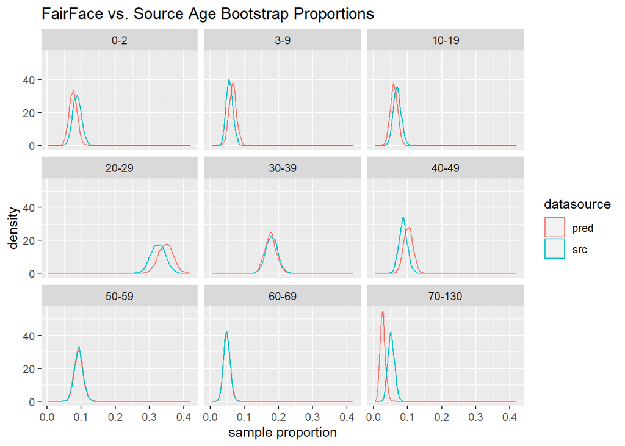

```r
#age plots
ff_bootstrap_data %>% filter(test_prop=='age_bins',test_gender=='All',test_race=='All') %>%
  mutate(test_age=factor(test_age,levels=f)) %>%
  ggplot()+geom_density(aes(x=value,color=datasource)) + facet_wrap(~test_age)+ xlab('sample proportion')+ ggtitle('FairFace vs. Source Age Bootstrap Proportions')
```

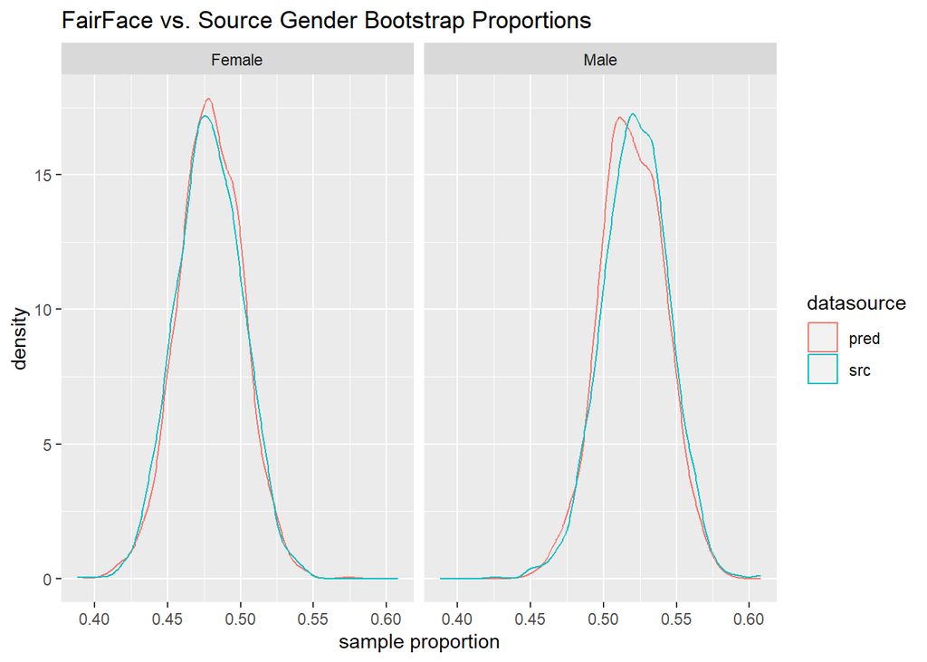

```r
#gender plots
ff_bootstrap_data %>% filter(test_prop=='genders',test_age=='All',test_race=='All') %>% ggplot()+geom_density(aes(x=value,color=datasource)) + facet_wrap(~test_gender)+  xlab('sample proportion')+ ggtitle('FairFace vs. Source Gender Bootstrap Proportions')
```

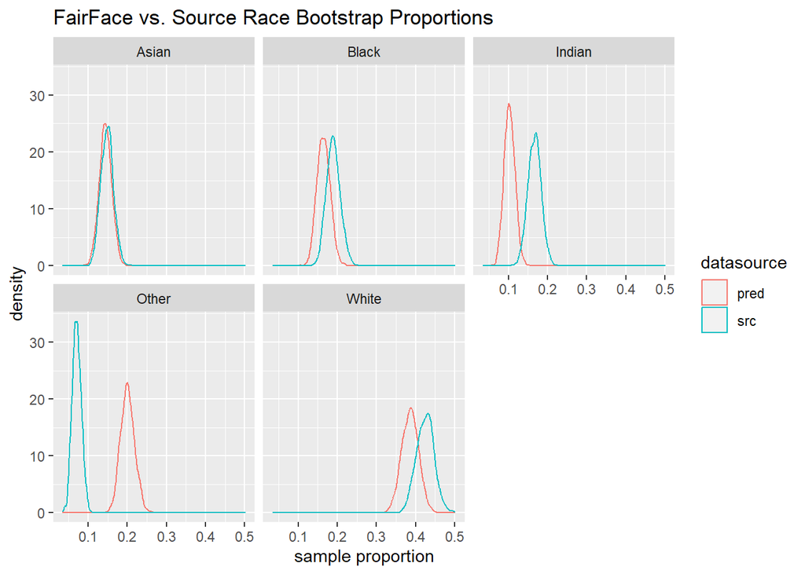

```r
#race plots
ff_bootstrap_data %>% filter(test_prop=='races',test_age=='All',test_gender=='All') %>% ggplot()+geom_density(aes(x=value,color=datasource)) + facet_wrap(~test_race)+ xlab('sample proportion')+ ggtitle('FairFace vs. Source Race Bootstrap Proportions')
```

```r
ff_bootstrap %>% filter(model_p_value > 0.003)
```

```
## # A tibble: 9 × 7
##   model test_prop test_race test_gender test_age model_p_value model_power
##   <chr> <chr>     <chr>     <chr>       <chr>            <dbl>       <dbl>
## 1 test  races     Black     Female      3-9            0.0177         1.00
## 2 test  age_bins  Asian     Male        0-2            0.00786        1.00
## 3 test  age_bins  Asian     Female      40-49          0.813          1.00
## 4 test  age_bins  Asian     All         50-59          0.356          1.00
## 5 test  races     Asian     All         50-59          0.00837        1.00
## 6 test  age_bins  All       All         50-59          0.628          1.00
## 7 test  age_bins  Other     Female      60-69          0.0936         1.00
## 8 test  age_bins  All       All         60-69          0.307          1.00
## 9 test  genders   All       Female      All            0.388          1.00
```